# Unit 10: For Live Session

#### Seasonal

First we read in the data collected from tswge.

```r
x = data("nottem")
```

Convert the data to time series

```r
x=ts(nottem)
```

Plot the data and see seasonality in the sample autocorrelations

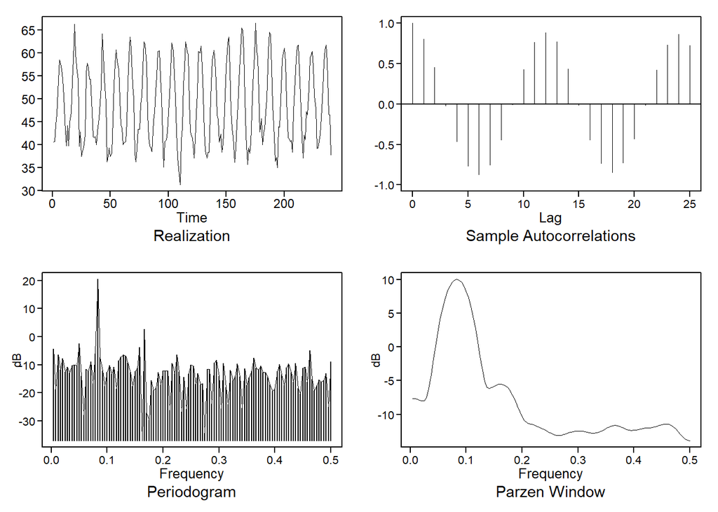

[output not shown]

[output cut: 58 more lines]

```r
plotts.sample.wge(x)
```

The behavior in the realization tends to repeat every 12th (s) time periods.

The sample autocorrelations large at s12.

A seasonal model with season s=12 make sense.

Estimate the parameters of the “stationarized data”.

```r
# overfit factor table of 24
over.x=est.ar.wge(x,p=24, factor = TRUE,type = 'burg')
```

```
##
## Coefficients of Original polynomial:
## 0.2822 0.0460 -0.0459 -0.1106 -0.0071 -0.0139 0.0114 -0.0465 0.0114 -0.0637 0.0857 0.0344 0.1543 -0.0020 -0.0919 -0.0892 0.0973 -0.0493 0.0252 -0.1075 0.0090 0.1102 0.0574 0.2786
##
## Factor                 Roots                Abs Recip    System Freq
## 1-1.7293B+0.9992B^2    0.8654+-0.5020i      0.9996       0.0837
## 1-1.0044B+0.9684B^2    0.5186+-0.8739i      0.9841       0.1648
## 1-0.9690B              1.0320               0.9690       0.0000
## 1-1.8596B+0.9274B^2    1.0026+-0.2703i      0.9630       0.0419
## 1+1.8569B+0.9181B^2   -1.0112+-0.2580i      0.9582       0.4602
## 1-1.3422B+0.9151B^2    0.7334+-0.7449i      0.9566       0.1262
## 1+1.6503B+0.9094B^2   -0.9074+-0.5256i      0.9536       0.4164
## 1+1.3074B+0.9081B^2   -0.7199+-0.7635i      0.9529       0.3703
## 1+0.4746B+0.8748B^2   -0.2713+-1.0342i      0.9353       0.2908
## 1-0.4004B+0.8629B^2    0.2320+-1.0512i      0.9289       0.2154
## 1+0.8949B+0.8450B^2   -0.5295+-0.9503i      0.9192       0.3309
## 1-0.0502B+0.8147B^2    0.0308+-1.1074i      0.9026       0.2456
## 1+0.8888B             -1.1252               0.8888       0.5000
##
##
```

Compare factors in overfit factor table with those for $(1 - B^s)$.

```r
factor.wge(p=c(0,0,0,0,0,0,0,0,0,0,0,1))
```

```
##
## Coefficients of Original polynomial:
## 0.0000 0.0000 0.0000 0.0000 0.0000 0.0000 0.0000 0.0000 0.0000 0.0000 0.0000 1.0000
##
## Factor                 Roots                Abs Recip    System Freq
## 1-1.0000B+1.0000B^2    0.5000+-0.8660i      1.0000       0.1667
## 1-1.0000B              1.0000               1.0000       0.0000
## 1-1.7321B+1.0000B^2    0.8660+-0.5000i      1.0000       0.0833
## 1+1.0000B+1.0000B^2   -0.5000+-0.8660i      1.0000       0.3333
## 1-0.0000B+1.0000B^2    0.0000+-1.0000i      1.0000       0.2500
## 1+1.7321B+1.0000B^2   -0.8660+-0.5000i      1.0000       0.4167
## 1+1.0000B             -1.0000               1.0000       0.5000
##
##
```

There is a somewhat close match so we will transform the data.

**Transformed data by $(1-B^{12})$**

```r
# Transform differenced data with "seasonal difference"
y=artrans.wge(x,phi.tr=c(0,0,0,0,0,0,0,0,0,0,0,1))
```

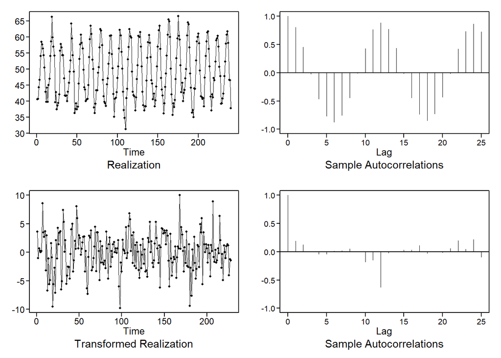

The data looks somewhat stationary. The next step is to model the transformed data with a $(1-B^{12})$

```r
# find the WNV
wnv=sd(y)^2
```

** Final Model**
$$(1-B^{12})X_t=a_t\ \sigma^2_a=11.82$$

#### Signal Plus Noise with Cochrane-Orcutt

First we need to install the correct libraries.

```r
#install.packages("orcutt")
library(orcutt)
```

We will need to import the data and set up a data frame.

```r
# read in the data
x = read.csv("energydata_complete.csv", header = TRUE)
```

Convert the data to time series

```r
#Just looking at the Appliances data
x=ts(x$Appliances)
```

Setup a data frame.

```r
t = seq(1,19735,1)
df = data.frame(x = x, t= t)
```

Check the fit for OLS

```r
fit = lm(x~t, data = df)
summary(fit)
```

```
##
## Call:
## lm(formula = x ~ t, data = df)
##
## Residuals:
##    Min     1Q Median     3Q    Max
## -89.22 -47.92 -36.64   1.71 980.72
##
## Coefficients:
##               Estimate Std. Error t value Pr(>|t|)
## (Intercept) 99.4050856  1.4596479  68.102   <2e-16 ***
## t           -0.0001733  0.0001281  -1.353    0.176
## ---
## Signif. codes:  0 '***' 0.001 '**' 0.01 '*' 0.05 '.' 0.1 ' ' 1
##
## Residual standard error: 102.5 on 19733 degrees of freedom
## Multiple R-squared:  9.274e-05,  Adjusted R-squared:  4.207e-05
## F-statistic:  1.83 on 1 and 19733 DF,  p-value: 0.1761
```

Check the fit for Cochrane Orcutt

```r
cfit = cochrane.orcutt(fit)
summary(cfit)
```

```
## Call:
## lm(formula = x ~ t, data = df)
##
##                Estimate  Std. Error t value Pr(>|t|)
## (Intercept) 99.33401023  3.89439328  25.507   <2e-16 ***
## t           -0.00016004  0.00034169  -0.468   0.6395
## ---
## Signif. codes:  0 '***' 0.001 '**' 0.01 '*' 0.05 '.' 0.1 ' ' 1
##
## Residual standard error: 67.4468 on 19732 degrees of freedom
## Multiple R-squared:  0 ,  Adjusted R-squared:  0
## F-statistic: 0.2 on 1 and 19732 DF,  p-value: < 6.395e-01
##
## Durbin-Watson statistic
## (original):    0.49358 , p-value: 0e+00
## (transformed): 1.88531 , p-value: 3.714e-16
```